# PR12 - Data Wrangling

## 4.2. `.`의 역할

- `.`의 역할에 대해서 알아봅시다.
- 일반적으로 %>% 연산자만 사용하시게 되면 제일 첫 인수에 자동으로 배정이 됩니다.

```r
head(iris, 3)
```

```
##   Sepal.Length Sepal.Width Petal.Length Petal.Width Species
## 1          5.1         3.5          1.4         0.2  setosa
## 2          4.9         3.0          1.4         0.2  setosa
## 3          4.7         3.2          1.3         0.2  setosa
```

```r
iris %>% head(3) # = head(., 3)
```

```
##   Sepal.Length Sepal.Width Petal.Length Petal.Width Species
## 1          5.1         3.5          1.4         0.2  setosa
## 2          4.9         3.0          1.4         0.2  setosa
## 3          4.7         3.2          1.3         0.2  setosa
```

- 데이터를 넘겨줘야 할 인수의 위치가 첫번째가 아닐 경우 다음과 같은 에러를 확인할 수 있음
- `gsub()`는 찾아 바꾸는 함수로써, 사용방법은 `gsub(찾을문자나 숫자, 바꿀 문자나 숫자, 데이터)`

```r
a = c("bannananana", "an apple")
gsub("n", "l", a)
```

```
## [1] "ballalalala" "al apple"
```

```r
a %>% gsub("n", "l")
```

```
## [1] "l"
```

```r
gsub("n", "l", a)
```

```
## [1] "ballalalala" "al apple"
```

```r
a %>% gsub("n", "l", .)
```

```
## [1] "ballalalala" "al apple"
```

## 4.3. Chaining 예제

### 4.3.1. mtcars aggregate

```r
library(magrittr)
car_data =
  mtcars %>% #1
  subset(hp > 100) %>% #2
  aggregate(. ~ cyl, data = ., FUN = . %>% mean %>% round(2)) %>% #3
  transform(kpl = mpg %>% multiply_by(0.4251)) %>% #4
  print #5
```

```
##   cyl   mpg   disp     hp drat   wt  qsec   vs   am gear carb       kpl
## 1   4 25.90 108.05 111.00 3.94 2.15 17.75 1.00 1.00 4.50 2.00 11.010090
## 2   6 19.74 183.31 122.29 3.59 3.12 17.98 0.57 0.43 3.86 3.43  8.391474
## 3   8 15.10 353.10 209.21 3.23 4.00 16.77 0.00 0.14 3.29 3.50  6.419010
```

- 예제 해석
  - mtcars 데이터셋을(#1)
  - hp를 기준으로 100보다 큰 데이터만 추출한 후(#2)
  - cyl를 기준으로 각 변수들의 평균을 구한 다음에 소수점 둘째 자리까지 반올림을 한 후(#3)
  - kpl(kilometer per liter) 열을 만들어 mpg*0.4251을 수행하고(#4)
  - 만들어진 데이터를 출력(#5)과 동시에 car_data에 할당하는 과정입니다.
- 체인연산없이 실행

```r
car_data =
  transform(aggregate(
    . ~ cyl,
    data = subset(mtcars, hp > 100),
    FUN = function(x)
      round(mean(x), 2)
  ),
  kpl = mpg * 0.4251)
car_data
```

```
##   cyl   mpg   disp     hp drat   wt  qsec   vs   am gear carb       kpl
## 1   4 25.90 108.05 111.00 3.94 2.15 17.75 1.00 1.00 4.50 2.00 11.010090
## 2   6 19.74 183.31 122.29 3.59 3.12 17.98 0.57 0.43 3.86 3.43  8.391474
## 3   8 15.10 353.10 209.21 3.23 4.00 16.77 0.00 0.14 3.29 3.50  6.419010
```

### 4.3.2. 예제 변환

- **2.1.** 예제

tidyr의 함수들도 chaining 연산과 함께 사용하면 직관적으로 사용할 수 있습니다.

```r
cases %>% gather(Year, n, 2:4)
```

```
##   country Year     n
## 1      FR 2011  7000
## 2      DE 2011  5800
## 3      US 2011 15000
## 4      FR 2012  6900
## 5      DE 2012  6000
## 6      US 2012 14000
## 7      FR 2013  7000
## 8      DE 2013  6200
## 9      US 2013 13000
```

- **3.7.** 예제

dplyr에서도 함께 쓰여 데이터를 그룹화하고 수치를 요약하는 등의 작업에 특화되어 있습니다.

```r
#비행기별 비행회수, 비행거리평균, 연착시간평균 산출
flights %>%
  group_by(tailnum) %>%
  summarise(
    count = n(),
    dist = mean(distance, na.rm = TRUE),
    delay = mean(arr_delay, na.rm = TRUE)
  )
```

```
## # A tibble: 4,044 × 4
##    tailnum count  dist  delay
##    <chr>   <int> <dbl>  <dbl>
##  1 D942DN      4  854. 31.5
##  2 N0EGMQ    371  676.  9.98
##  3 N10156    153  758. 12.7
##  4 N102UW     48  536.  2.94
##  5 N103US     46  535. -6.93
##  6 N104UW     47  535.  1.80
##  7 N10575    289  520. 20.7
##  8 N105UW     45  525. -0.267
##  9 N107US     41  529. -5.73
## 10 N108UW     60  534. -1.25
## # … with 4,034 more rows
```

# 5. tibble

## 5.1. `tibble` 생성

### `tibble()`

```r
tibble(x = 1:5,
       y = 1,
       Z = x ^ 2 + y)
```

```
## # A tibble: 5 × 3
##       x     y     Z
##   <int> <dbl> <dbl>
## 1     1     1     2
## 2     2     1     5
## 3     3     1    10
## 4     4     1    17
## 5     5     1    26
```

### `tribble()`

코드 단계에서 데이터를 입력받도록 하기 위해 존재하는 함수입니다.

```r
tribble(~ x, ~ y, ~ z,
        #--/----/----
        "a", 2, 3.6,
        "b", 1, 8.5)
```

```
## # A tibble: 2 × 3
##   x         y     z
##   <chr> <dbl> <dbl>
## 1 a         2   3.6
## 2 b         1   8.5
```

### `as_tibble()`

기존의 데이터 프레임을 tibble 형으로 전환 합니다.

```r
iris_tibble = as_tibble(iris) # 기존의 데이터 프레임을 tibble로
print(class(iris)) # 기존 데이터 프레임 클래스
```

```
## [1] "data.frame"
```

```r
print(class(iris_tibble)) # 새롭게 정의된 tibble 클래스 (데이터 프레임도)
```

```
## [1] "tbl_df"     "tbl"        "data.frame"
```

```r
head(iris_tibble)
```

```
## # A tibble: 6 × 5
##   Sepal.Length Sepal.Width Petal.Length Petal.Width Species
##          <dbl>       <dbl>        <dbl>       <dbl> <fct>
## 1          5.1         3.5          1.4         0.2 setosa
## 2          4.9         3            1.4         0.2 setosa
## 3          4.7         3.2          1.3         0.2 setosa
## 4          4.6         3.1          1.5         0.2 setosa
## 5          5           3.6          1.4         0.2 setosa
## 6          5.4         3.9          1.7         0.4 setosa
```

## 5.2. 데이터 불러오기

- 데이터를 읽어올 때, dataframe이 아닌 tibble로 읽어오기 위해서, 동일한 `tidyverse` 생태계에 속한 `readr` 패키지의 함수들을 필요로 합니다.
- 이미 `tidyverse` 를 library하였으므로 바로 이용 가능합니다.

### `read_csv(file)`

- 기존의 데이터 불러오기와 동일하게 파일명을 지정하여 해당 파일을 tibble로 읽어올 수 있습니다.

```r
read_csv("traffic(1).csv")
```

```
## ──────────────────────────────────────────────────────── Delimiter: "," chr
## (4): rpt.id, rpt.contents, info.tp, info.tit dbl (5): ...1, start.pos.x,
## start.pos.y, end.pos.x, end.pos.y date (2): occ.dtime, end.dtime time (1):
## reg.dtime
```

```
## # A tibble: 500 × 12
##     ...1 rpt.id   rpt.co…¹ info.tp info.…² occ.dtime  reg.d…³ end.dtime  start…⁴
##    <dbl> <chr>    <chr>    <chr>   <chr>   <date>     <time>  <date>       <dbl>
##  1     1 01149328 서부간…  A4      단순정… 2014-06-15 17:17   2014-06-15    127.
##  2     2 01149327 동부간…  A4      단순정… 2014-06-15 17:16   2014-06-15    127.
##  3     3 01149326 북부간…  A4      단순정… 2014-06-15 17:16   2014-06-15    127.
##  4     4 01149325 올림픽…  A4      단순정… 2014-06-15 17:15   2014-06-15    127.
##  5     5 01149324 강변북…  A1      단순사… 2014-06-15 17:15   2014-06-15    127.
##  6     6 01149323 내부순…  A4      단순정… 2014-06-15 17:14   2014-06-15    127.
##  7     7 01149322 평택-시… A4      단순정… 2014-06-15 17:14   2014-06-15      0
##  8     8 01149321 서울-춘… A4      단순정… 2014-06-15 17:13   2014-06-15    127.
##  9     9 01149320 천안-논… A4      단순정… 2014-06-15 17:13   2014-06-15    127.
## 10    10 01149319 영동고…  A4      단순정… 2014-06-15 17:12   2014-06-15    127.
## # … with 490 more rows, 3 more variables: start.pos.y <dbl>, end.pos.x <dbl>,
## #   end.pos.y <dbl>, and abbreviated variable names ¹rpt.contents, ²info.tit,
## #   ³reg.dtime, ⁴start.pos.x
```

### `read_csv(csv_url)`

- 외부에서 공개된 CSV 파일도 바로 읽어올 수 있습니다.
  - github, gist, google drive

```r
file_url = "https://gist.githubusercontent.com/theoroe3/8bc989b644adc24117bc66f50c292fc8/raw/f677a2ad811a9854c9d174178b0585a87569af60/tibbles_data.csv"
read_csv(file_url)
```

```
## # A tibble: 4 × 4
##    `<-`   `8`   `%` name
##   <dbl> <dbl> <dbl> <chr>
## 1     1     2  0.25 t
## 2     2     4  0.25 h
## 3     3     6  0.25 e
## 4     4     8  0.25 o
```

### locale 설정

- 한글이 포함된 데이터를 읽어올 때, `read.csv` 에서 `fileEncdoing` 으로 조정을 하였습니다.
- read_csv 에서는 주로 `locale` 인자를 설정해 주어야 하는데, 통상적으로 `locale("ko",encoding="euc-kr")` 와 같이 설정해줍니다.

### 5.3. 결측값 처리

결측값을 처리하는 방법으로 결측값이 있는 행을 삭제하거나, 다른 값으로 치환하는 방법이 있습니다.

- `drop_na()` 는 결측값이 있는 행을 삭제하는 함수입니다.
- `fill()` 은 인접한 값들을 이용해서 결측값을 치환하는 방법입니다.
- `replace_na()` 는 특정한 값을 이용해서 결측값을 치환하는 방법입니다.

### `drop_na()`

```r
library(dplyr)
df = tibble(x = c(1, 2, NA) , y = c("a", NA, "b"))
df %>% drop_na()
```

```
## # A tibble: 1 × 2
##       x y
##   <dbl> <chr>
## 1     1 a
```

```r
df %>% drop_na(x)
```

```
## # A tibble: 2 × 2
##       x y
##   <dbl> <chr>
## 1     1 a
## 2     2 <NA>
```

```r
vars = "y"
df %>% drop_na(x, any_of(vars))
```

```
## # A tibble: 1 × 2
##       x y
##   <dbl> <chr>
## 1     1 a
```

### `fill()`

```r
sales = tibble::tribble(
  ~quarter, ~year, ~sales,
  "Q1", 2000, 66013,
  "Q2", NA, 69182,
  "Q3", NA, 53175,
  "Q4", NA, 21001,
  "Q1", 2001, 46036,
  "Q2", NA, 58842,
  "Q3", NA, 44568,
  "Q4", NA, 50197,
  "Q1", 2002, 39113,
  "Q2", NA, 41668,
  "Q3", NA, 30144,
  "Q4", NA, 52897,
  "Q1", 2004, 32129,
  "Q2", NA, 67686,
  "Q3", NA, 31768,
  "Q4", NA, 49094
)
sales %>% fill(year)
```

```
## # A tibble: 16 × 3
##    quarter  year sales
##    <chr>   <dbl> <dbl>
##  1 Q1       2000 66013
##  2 Q2       2000 69182
##  3 Q3       2000 53175
##  4 Q4       2000 21001
##  5 Q1       2001 46036
##  6 Q2       2001 58842
##  7 Q3       2001 44568
##  8 Q4       2001 50197
##  9 Q1       2002 39113
## 10 Q2       2002 41668
## 11 Q3       2002 30144
## 12 Q4       2002 52897
## 13 Q1       2004 32129
## 14 Q2       2004 67686
## 15 Q3       2004 31768
## 16 Q4       2004 49094
```

### `fill(.direction="up")`

```r
tidy_pets = tibble::tribble(
  ~rank, ~pet_type, ~breed,
  1L, NA, "Boston Terrier",
  2L, NA, "Retrievers (Labrador)",
  3L, NA, "Retrievers (Golden)",
  4L, NA, "French Bulldogs",
  5L, NA, "Bulldogs",
  6L, "Dog", "Beagles",
  1L, NA, "Persian",
  2L, NA, "Maine Coon",
  3L, NA, "Ragdoll",
  4L, NA, "Exotic",
  5L, NA, "Siamese",
  6L, "Cat", "American Short"
)
tidy_pets %>%
  fill(pet_type, .direction = "up")
```

```
## # A tibble: 12 × 3
##     rank pet_type breed
##    <int> <chr>    <chr>
##  1     1 Dog      Boston Terrier
##  2     2 Dog      Retrievers (Labrador)
##  3     3 Dog      Retrievers (Golden)
##  4     4 Dog      French Bulldogs
##  5     5 Dog      Bulldogs
##  6     6 Dog      Beagles
##  7     1 Cat      Persian
##  8     2 Cat      Maine Coon
##  9     3 Cat      Ragdoll
## 10     4 Cat      Exotic
## 11     5 Cat      Siamese
## 12     6 Cat      American Short
```

### `replace_na()`

```r
df = tibble(x = c(1, 2, NA) , y = c("a", NA, "b"))
df %>% replace_na(list(x = 0, y = "unknown"))
```

```
## # A tibble: 3 × 2
##       x y
##   <dbl> <chr>
## 1     1 a
## 2     2 unknown
## 3     0 b
```

```r
df %>% dplyr::mutate(x = replace_na(x, 0))
```

```
## # A tibble: 3 × 2
##       x y
##   <dbl> <chr>
## 1     1 a
## 2     2 <NA>
## 3     0 b
```

# PR12 연습문제

```r
data1 = read.csv("data1(1).csv", fileEncoding = "EUC-KR")
data2 = read.csv("data2(1).csv", fileEncoding = "EUC-KR")
```

### 문제 1

- data1.csv에는 지역별 온실가스 배출량 정보가 있으며, data2.csv에는 지역 별 기업 수가 있다.
- data1.csv는 data1이라는 변수에 저장하고 data2.csv는 data2이라는 변수에 저장하고, 두 변수를 `시도`를 기준으로 하나의 데이터프레임으로 만드시오.
- 조건1. wide 형태를 long으로 바꾸어야 함.
- 조건2. join을 진행하여야 함.
- 조건3. head(, 10)을 통해 상위 10개만 출력하시오.

```r
data2_long = gather(data2, 광역시도명, n, 2:18)
fetched_data = inner_join(data1, data2_long)
head(fetched_data, 10)
```

```
##    년도 광역시도명 전체온실가스배출량 X1인당인구배출량
## 1  2019 서울특별시           11366609            1.168
## 2  2019 서울특별시           11366609            1.168
## 3  2019 서울특별시           11366609            1.168
## 4  2019 서울특별시           11366609            1.168
## 5  2019 부산광역시            6747556            1.977
## 6  2019 부산광역시            6747556            1.977
## 7  2019 부산광역시            6747556            1.977
## 8  2019 부산광역시            6747556            1.977
## 9  2019 대구광역시            4003434            1.642
## 10 2019 대구광역시            4003434            1.642
##    관리업체1개당.온실가스배출량 사업장1개당온실가스.배출량       등록현황     n
## 1                      35744.05                   3305.208   규모(소기업)    19
## 2                      35744.05                   3305.208   규모(중기업)   363
## 3                      35744.05                   3305.208   규모(대기업) 11206
## 4                      35744.05                   3305.208 규모(중견기업)     9
## 5                      47518.00                   9032.873   규모(소기업)    33
## 6                      47518.00                   9032.873   규모(중기업)   527
## 7                      47518.00                   9032.873   규모(대기업) 10202
## 8                      47518.00                   9032.873 규모(중견기업)     1
## 9                      33642.30                   8087.745   규모(소기업)    30
## 10                     33642.30                   8087.745   규모(중기업)   438
```

### 문제2.

group_by, filter 함수를 사용하여 문제 1의 데이터를 필요에 따라 변형/집계/추출한 다음 시각화를 진행하시오.

부산 시의 전체온실가스배출량의 연도 별 추이를, 또 연도 별 사업장 등록형태 별 비중도 보고 싶어요.

```r
entire_pusan_corporative = sum((data2_long %>% filter(광역시도명 == '부산광역시'))$n)
co2_pusan_by_year = fetched_data %>%
  filter(광역시도명 == '부산광역시') %>%
  group_by(년도) %>%
  select(전체온실가스배출량, 등록현황, n) %>%
  mutate(
    전체온실가스배출량 = n / entire_pusan_corporative * 전체온실가스배출량
  )
```

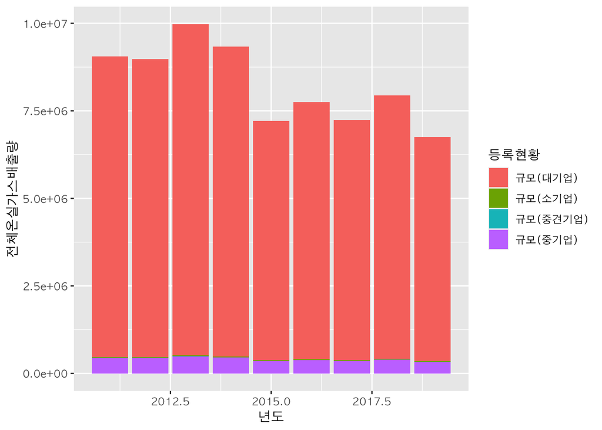

```r
ggplot(co2_pusan_by_year, aes(fill = 등록현황, y = 전체온실가스배출량, x = 년도)) +
  geom_bar(position = "stack", stat = "identity") +
  theme_gray(base_family = 'AppleGothic')
```

# PR12 도전문제

### 제공되는 데이터를 이용하여 수업시간에 배운 함수들을 최대한 활용해 주세요.

- 조건1. 최소 10줄 이상의 코드를 작성하세요.
- 조건2. tidyr, dplyr, magrittr의 함수를 최소 1개 이상씩 사용하세요.
- 조건3. 주석을 최대한 상세하게 추가해 주세요.
1. 2020년 1월 한 달 동안 일 별 대출 금액 추이와 일 별 대출 금액 중 내방 고객 대 온라인 고객의 차지하는 비율을 시각적으로 확인하고 싶어요.

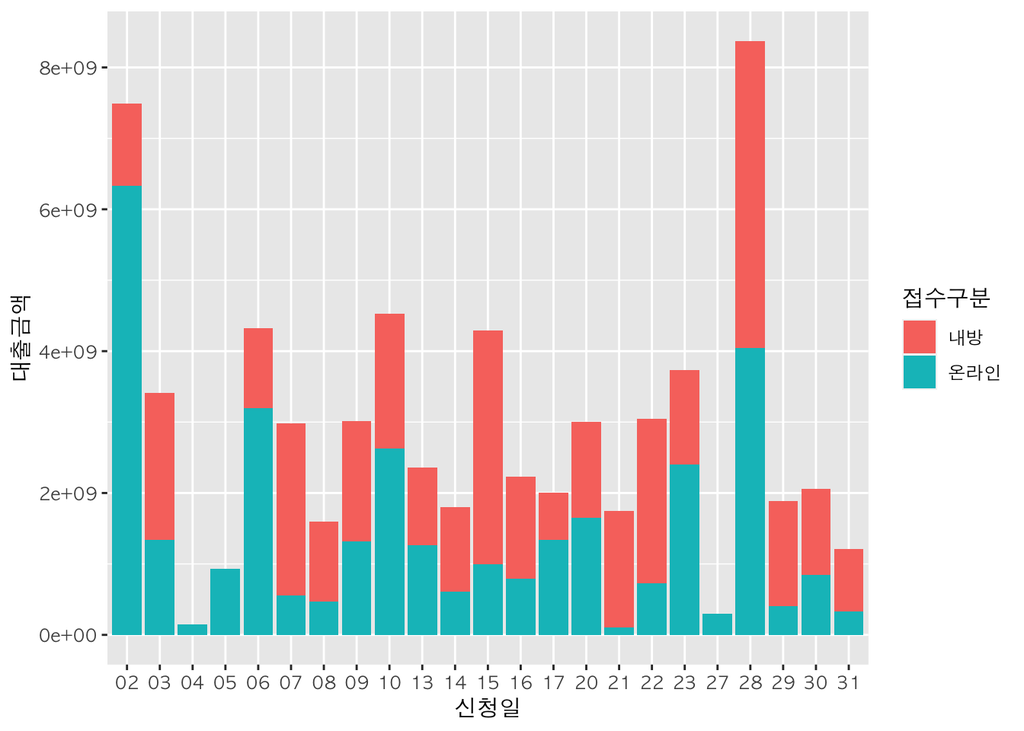

```r
# 경기도 지원 대출금 파일을 메모리에 올리기
supportive_g_money_raw = read.csv('G-money지원현황.csv', fileEncoding = 'euc-kr')
# supportive_g_money_raw를 pipeline을 통해 전달
supportive_g_money_data = supportive_g_money_raw %>%
  # 신청일자 열을 년월일 각자의 열로 분리하는데, 하이픈을 기준으로 구분
  separate(col = 신청일자, sep = '-', into = c('신청년', '신청월', '신청일')) %>%
  # 신청년과 신청월을 필터링
  filter(신청년 == '2020', 신청월 == '01')

# 시각화를 위해 ggplot을 이용, 접수구분 열로 색 구분을, 대출금액의 합계를 y축, 신청일을 x축으로 하고자 함
ggplot(supportive_g_money_data, aes(fill = 접수구분, y = 대출금액, x = 신청일)) +
  # 갯수를 세는 게 아닌, 이미 값이 구해져 있기 때문에 stat 파라미터를 identity로 설정하여야
  geom_bar(position = "stack", stat = "identity") +
  theme_gray(base_family = 'AppleGothic')
```

2. 금리가 4퍼센트가 넘는 지원대출의 신청년월에 따른 대출금액 추이를 보고 싶어요. 또 신청년월 별로 자금대분류 별 비중도 보고 싶어요.

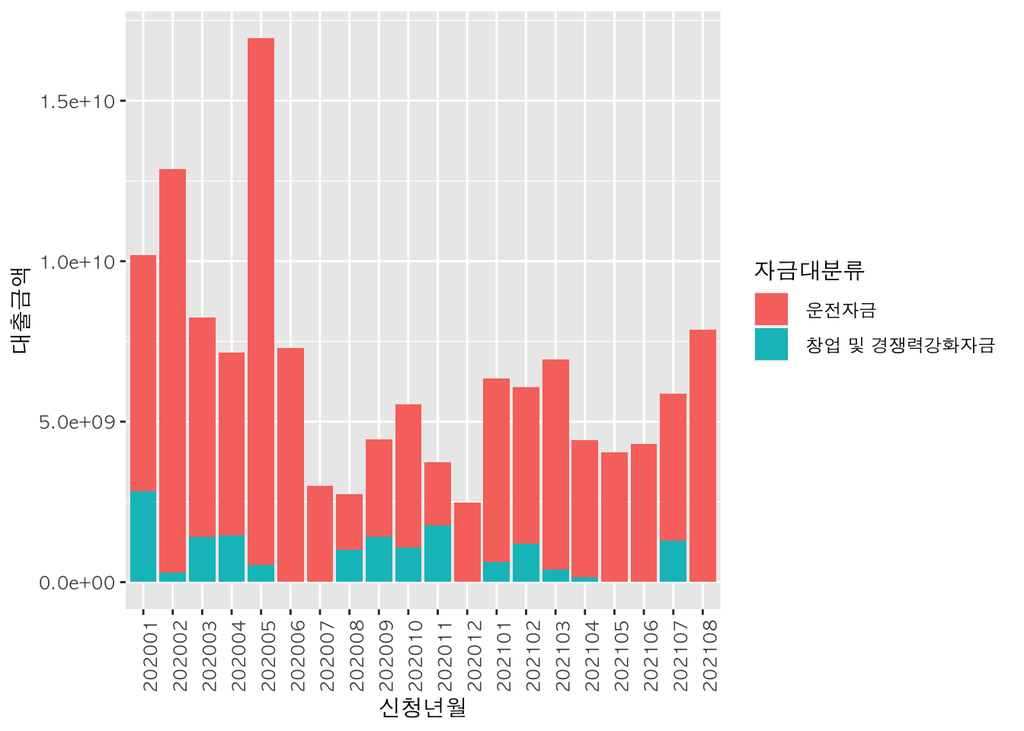

```r
# supportive_g_money_raw를 pipeline을 통해 전달
supportive_g_money_data_1 = supportive_g_money_raw %>%
  # 금리가 4퍼센트 이상만 필터링
  filter(대출금리 > 4) %>%
  # 신청일자 열을 년월일 각자의 열로 분리하는데, 하이픈을 기준으로 구분
  separate(col = 신청일자, sep = '-', into = c('신청년', '신청월', '신청일')) %>%
  # 신청년 열과 신청월 열을 하나의 열로 관리
  unite(col = 신청년월, 신청년, 신청월, sep = '')

# 시각화를 위해 ggplot을 이용, 자금대분류 열로 색 구분을, 대출금액의 합계를 y축, 신청일을 x축으로 하고자 함
ggplot(supportive_g_money_data_1, aes(fill = 자금대분류, y = 대출금액, x = 신청년월)) +
  # 갯수를 세는 게 아닌, 이미 값이 구해져 있기 때문에 stat 파라미터를 identity로 설정하여야
  geom_bar(position = "stack", stat = "identity") +
  theme_gray(base_family = 'AppleGothic') +
  theme(axis.text.x=element_text(angle=90, hjust=1))
```